# OkCupid Data

14/10/2020

We will investigate the OKCupid Data and see if we can predict if a user is a STEM major or not, based on the data provided. First we will perform some EDA to look at the data, and then we will use the Tidymodels framework to easily create machine learning models. If you wish to view the results, use the contents tab on the left to skip to the **Performance on Test Set** section.

```r
library(modeldata)
library(tidyverse)
library(skimr)
library(tidymodels)
```

# 1 EDA

## 1.1 Basic EDA

```r
data("okc")

skim(okc)
```

Data summary

| Name | okc |
| --- | --- |
| Number of rows | 59855 |
| Number of columns | 6 |
| _______________________ |  |
| Column type frequency: |  |
| character | 2 |
| Date | 1 |
| factor | 1 |
| numeric | 2 |
| ________________________ |  |
| Group variables | None |

**Variable type: character**

| skim_variable | n_missing | complete_rate | min | max | empty | n_unique | whitespace |
| --- | --- | --- | --- | --- | --- | --- | --- |
| diet | 24360 | 0.59 | 5 | 19 | 0 | 18 | 0 |
| location | 0 | 1.00 | 4 | 19 | 0 | 135 | 0 |

**Variable type: Date**

| skim_variable | n_missing | complete_rate | min | max | median | n_unique |
| --- | --- | --- | --- | --- | --- | --- |
| date | 0 | 1 | 2011-06-27 | 2012-07-01 | 2012-06-27 | 371 |

**Variable type: factor**

| skim_variable | n_missing | complete_rate | ordered | n_unique | top_counts |
| --- | --- | --- | --- | --- | --- |
| Class | 0 | 1 | FALSE | 2 | oth: 50316, ste: 9539 |

**Variable type: numeric**

| skim_variable | n_missing | complete_rate | mean | sd | p0 | p25 | p50 | p75 | p100 | hist |
| --- | --- | --- | --- | --- | --- | --- | --- | --- | --- | --- |
| age | 0 | 1 | 32.34 | 9.46 | 18 | 26 | 30 | 37 | 110 | ▇▂▁▁▁ |
| height | 2 | 1 | 68.29 | 3.99 | 1 | 66 | 68 | 71 | 95 | ▁▁▁▇▁ |

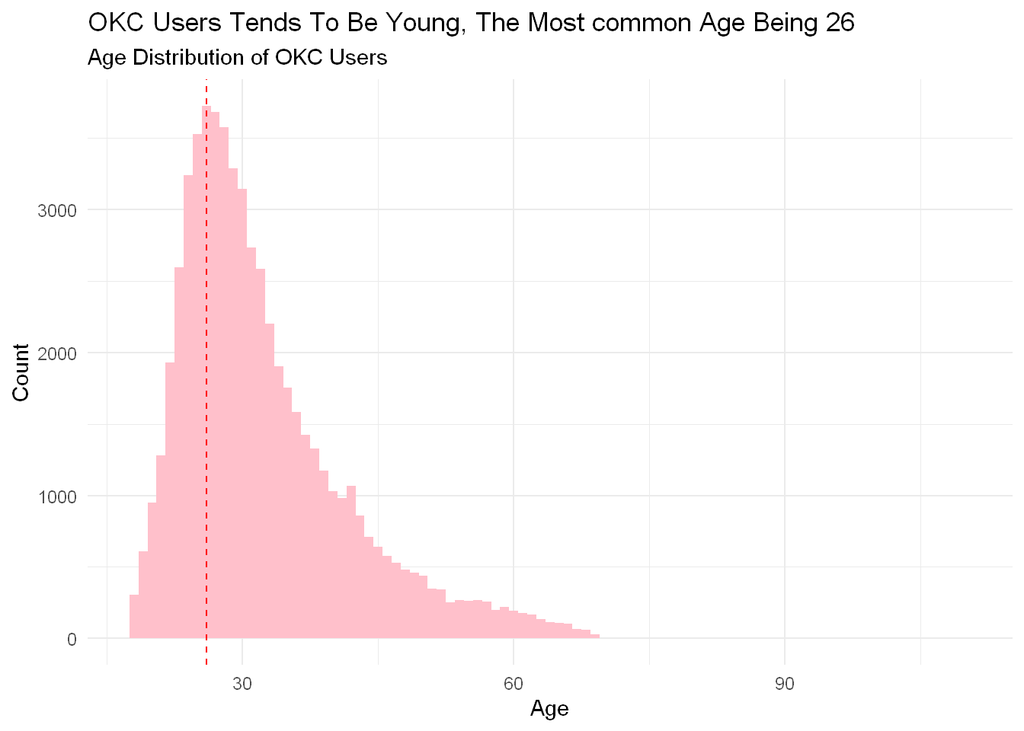

```r
okc %>%
  ggplot(aes(x=age))+
  geom_histogram(binwidth = 1,fill="pink")+
  theme_minimal()+
  labs(title="OKC Users Tends To Be Young, The Most common Age Being 26",subtitle="Age Distribution of OKC Users",x="Age",y="Count")+
  geom_vline(xintercept = 26, col="red",lty=2)
```

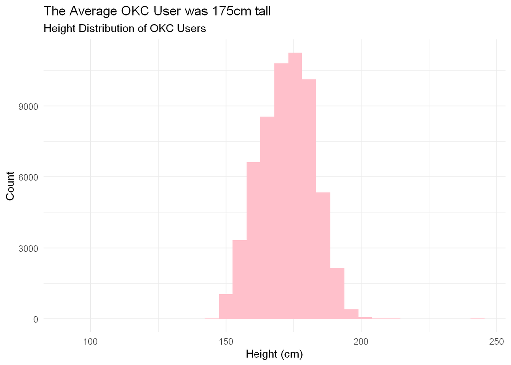

```r
okc %>%
  filter(height > 30)%>%
  mutate(height = height/0.39370 )%>%
  ggplot(aes(x=height))+
  geom_histogram(bins=30,fill="pink")+
  theme_minimal()+
  labs(title="The Average OKC User was 175cm tall",subtitle="Height Distribution of OKC Users",x="Height (cm)",y="Count")
```

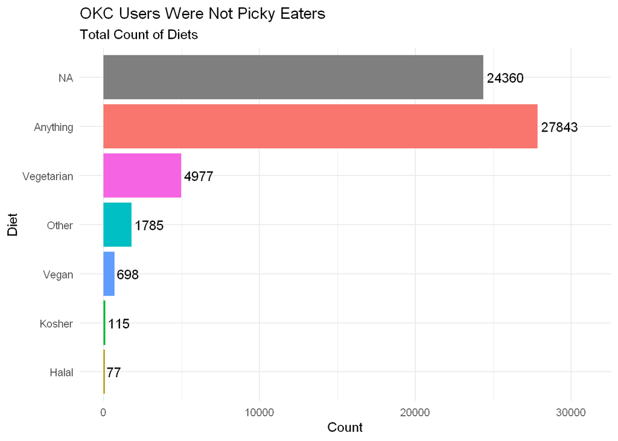

```r
okc %>%
  mutate(diet = str_remove(diet,"strictly"),
         diet = str_remove(diet,"mostly"),
         diet = str_remove(diet, " "),
         diet = str_to_title(diet),
         )%>%
  count(diet)%>%
  arrange(desc(n))%>%
  ggplot(aes(x=n,y=reorder(diet,n),fill=diet))+
  geom_col(show.legend = F)+
  geom_text(aes(label=n),hjust=-.1)+
  theme_minimal()+
  lims(x=c(0,31000))+
  labs(title = "OKC Users Were Not Picky Eaters",subtitle="Total Count of Diets",x="Count",y="Diet")
```

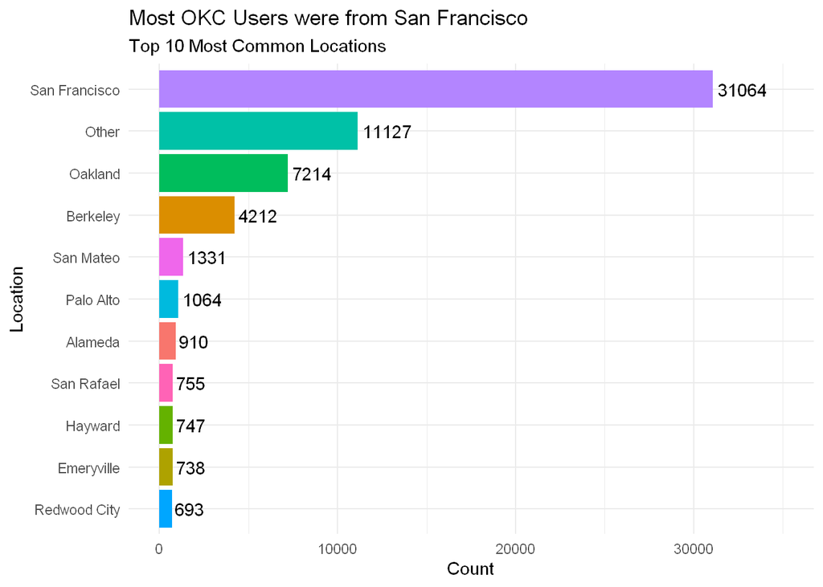

```r
okc %>%
  mutate(location = fct_lump_n(location,n=10) )%>%
  mutate (location =  str_to_title(location))%>%
  count(location) %>%
  arrange(-n)%>%
  ggplot(aes(x=n,y=reorder(location,n),fill=location))+
  geom_col(show.legend = F)+
  geom_text(aes(label=n),hjust=-.1)+
  theme_minimal()+
  lims(x=c(0,35000))+
  labs(title = "Most OKC Users were from San Francisco",subtitle="Top 10 Most Common Locations",x="Count",y="Location")
```

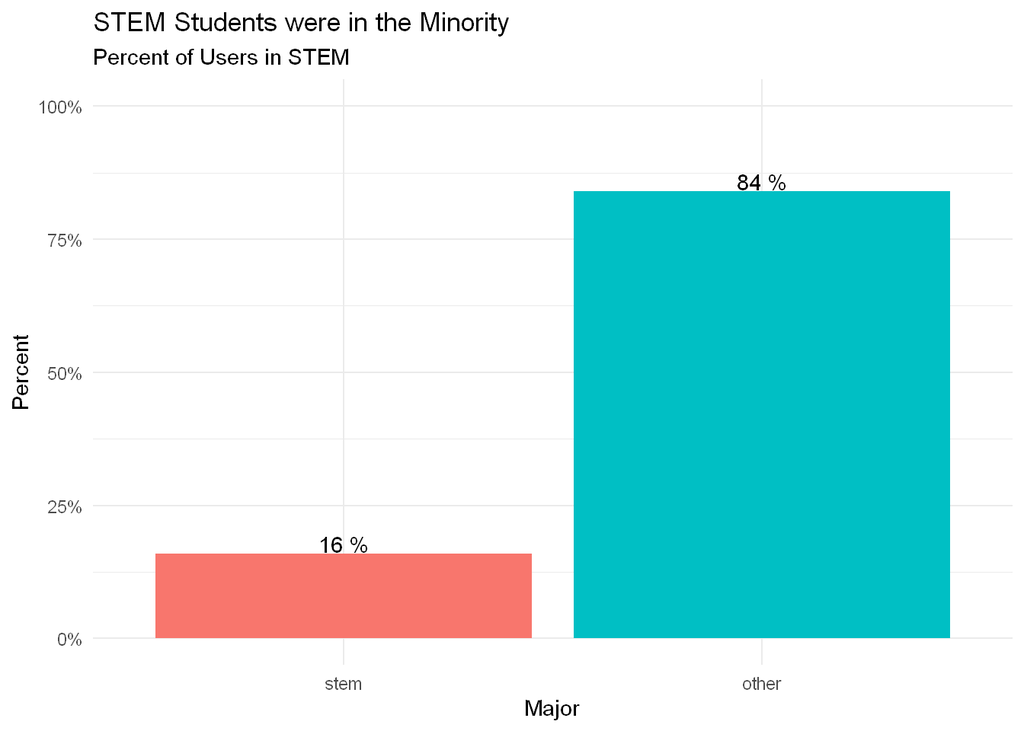

```r
okc %>%
  count(Class)%>%
  mutate(prop=n/sum(n)) %>%
  ggplot(aes(x=Class,y=prop,fill=Class))+
  geom_col(show.legend = FALSE)+
  theme_minimal()+
  scale_y_continuous(labels=scales::percent_format(),limits = c(0,1))+
  geom_text(aes(label= paste(round(prop*100),"%"),vjust=-.1) )+
  labs(title="STEM Students were in the Minority",subtitle="Percent of Users in STEM",x="Major",y="Percent")
```

Were the age demographics different for different locations?

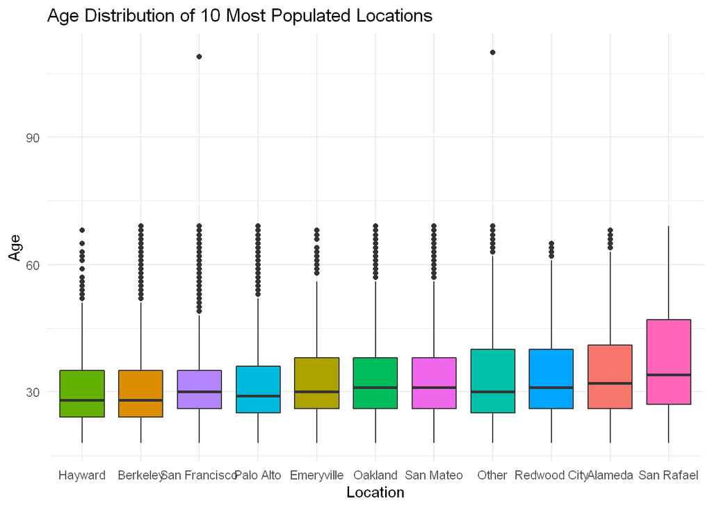

```r
okc %>%
  mutate(location = fct_lump_n(location,n=10) )%>%
  mutate (location =  str_to_title(location)) %>%
  ggplot(aes(x=reorder(location,age),y=age,fill=location))+
  #geom_violin(show.legend = F,draw_quantiles = c(.25,.50,.75))+
  geom_boxplot(show.legend = F)+
  theme_minimal()+
  labs(title="Age Distribution of 10 Most Populated Locations",x="Location",y="Age")
```

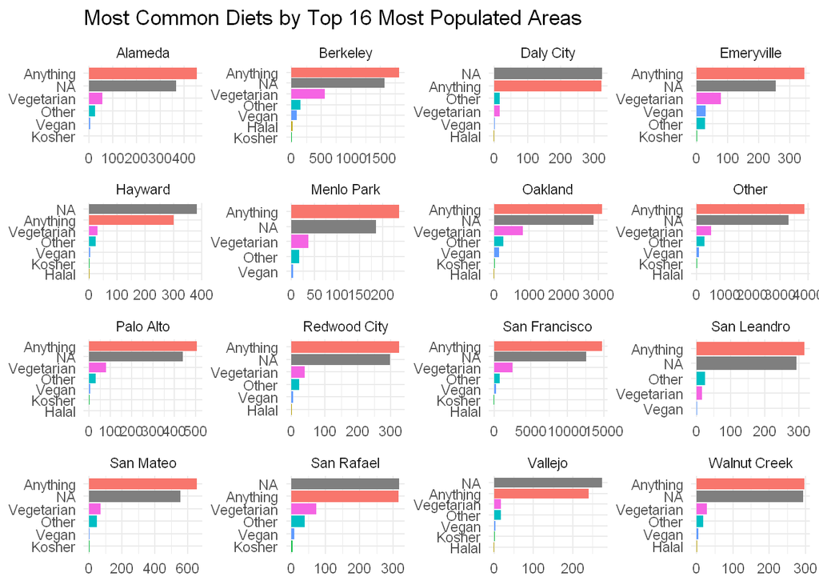

```r
okc %>%
  mutate(diet = str_remove(diet,"strictly"),
         diet = str_remove(diet,"mostly"),
         diet = str_remove(diet, " "),
         diet = str_to_title(diet),
     location = fct_lump_n(location,n=15),
     location =  str_to_title(location)
  )%>%
  group_by(location)%>%
  count(diet)%>%
  ungroup()%>%
  ggplot(aes(x=n,   y=tidytext::reorder_within(diet,n,location),fill=diet ))+
  geom_col(show.legend = F)+
  facet_wrap(.~location,scales = "free")+
  tidytext::scale_y_reordered()+
  #geom_text(aes(label=n,),hjust=.5)+
  theme_minimal()+
  labs(title="Most Common Diets by Top 16 Most Populated Areas",x=NULL,y=NULL)
```

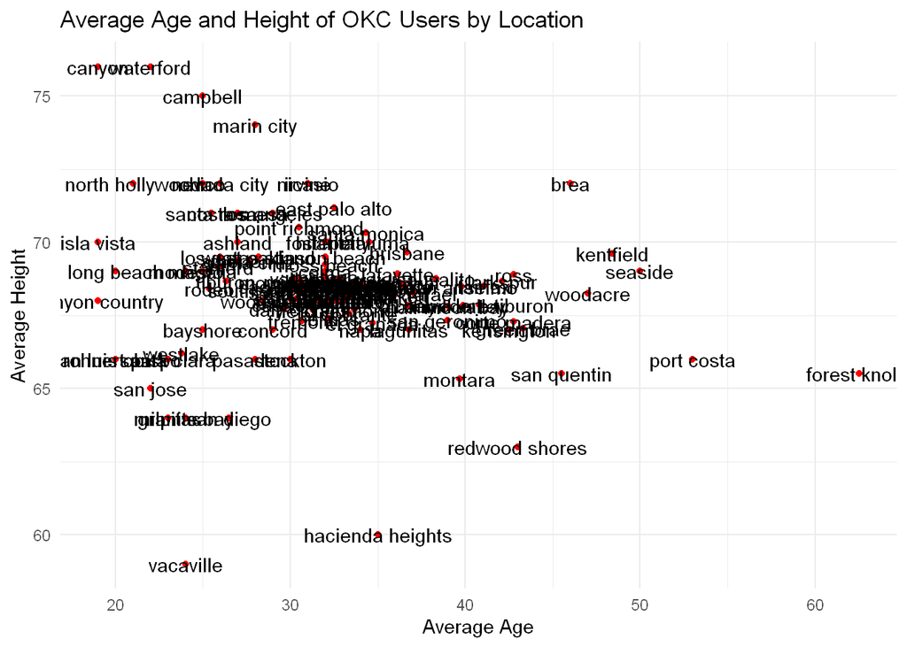

```r
okc %>%
  filter(height > 30)%>%
  na.omit(height)%>%
  group_by(location)%>%
mutate( avg_height = mean(height),
          avg_age = mean(age)
  )%>%
  ungroup()%>%
  distinct(location,.keep_all = TRUE) %>%
  ggplot(aes(x=avg_age,y=avg_height))+
  geom_point(col="red")+
  geom_text(aes(label=location))+
  theme_minimal()+
  labs(title="Average Age and Height of OKC Users by Location",x="Average Age",y="Average Height")
```

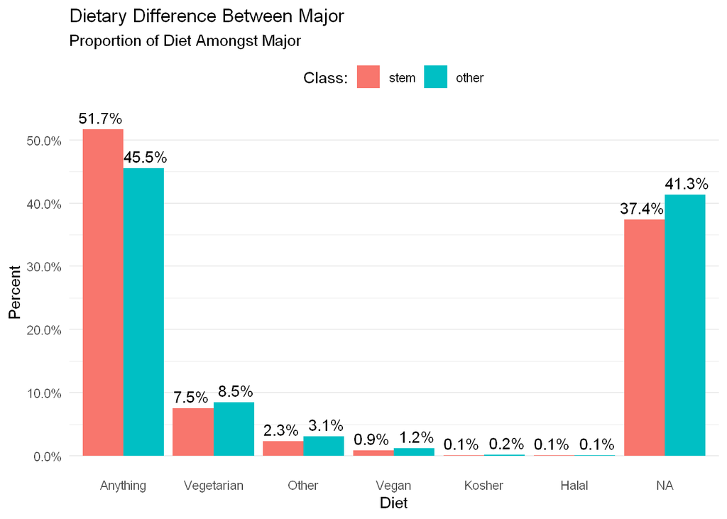

```r
okc %>%
  #filter( !is.na(diet)) %>%
  mutate(diet = str_remove(diet,"strictly"),
         diet = str_remove(diet,"mostly"),
         diet = str_remove(diet, " "),
         diet = str_to_title(diet),
     location = fct_lump_n(location,n=15),
     location =  str_to_title(location)
  ) %>%
  group_by(diet,Class)%>%
  count(diet)%>%
  ungroup(diet)%>%
  mutate(prop=n/sum(n)) %>%
  ggplot(aes(x=reorder(diet,-prop),y=prop,fill=Class))+
  geom_col(position = position_dodge())+
  geom_text(aes(label=  paste0(  round(prop*100,1),"%" ) ),position = position_dodge(width = 1),vjust=-.5)+
  scale_y_continuous(labels = scales::percent_format())+
  labs(title="Dietary Difference Between Major",subtitle = "Proportion of Diet Amongst Major",x="Diet",y="Percent",fill="Class:")+
    theme_minimal()+
  theme(legend.position = "top",
        panel.grid.major.x = element_blank() )
```

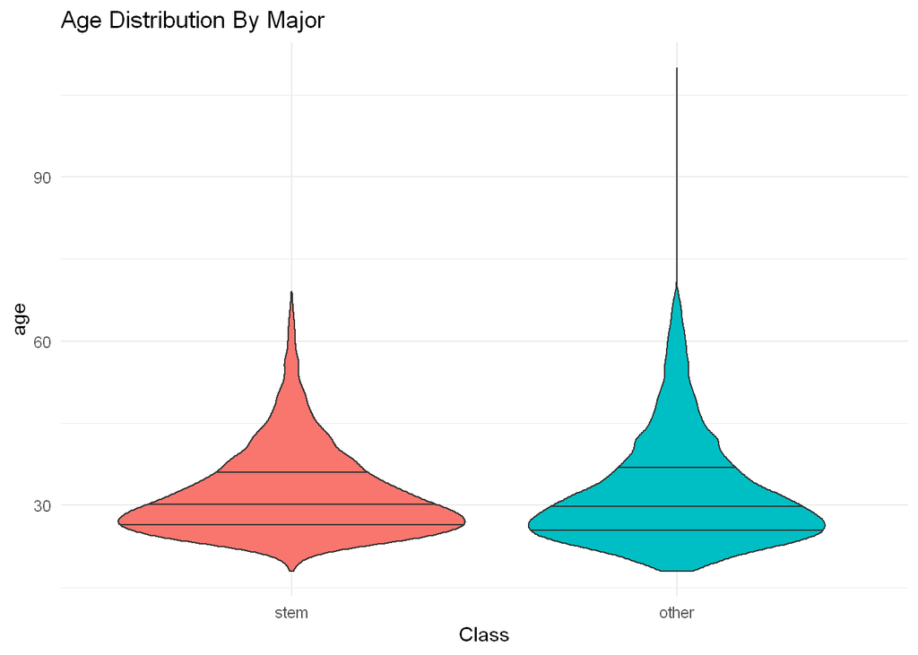

```r
ggplot(okc,aes(x=Class,y=age,fill=Class))+
  geom_violin(draw_quantiles = c(.25,.5,.75),show.legend = F)+
  theme_minimal()+
  labs(title="Age Distribution By Major")
```

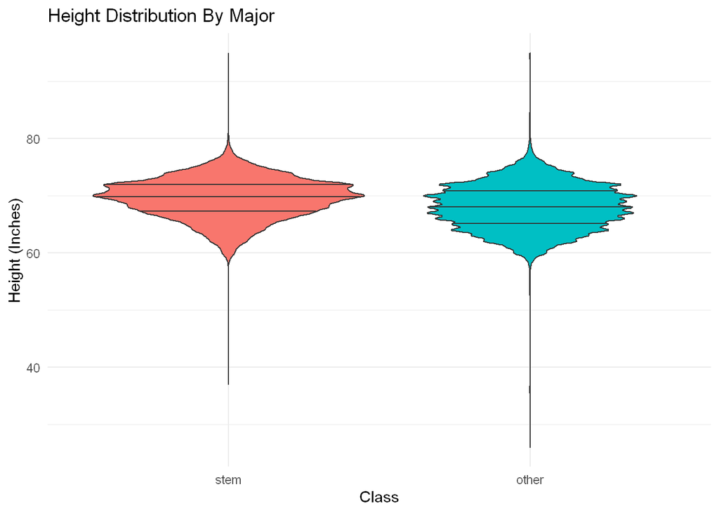

```r
okc %>%
  filter(height > 25) %>%
ggplot(aes(x=Class,y=height,fill=Class))+
  geom_violin(draw_quantiles = c(.25,.5,.75),show.legend = F)+
  #geom_boxplot(show.legend = F)+
  theme_minimal()+
  labs(title="Height Distribution By Major",y="Height (Inches)")
```

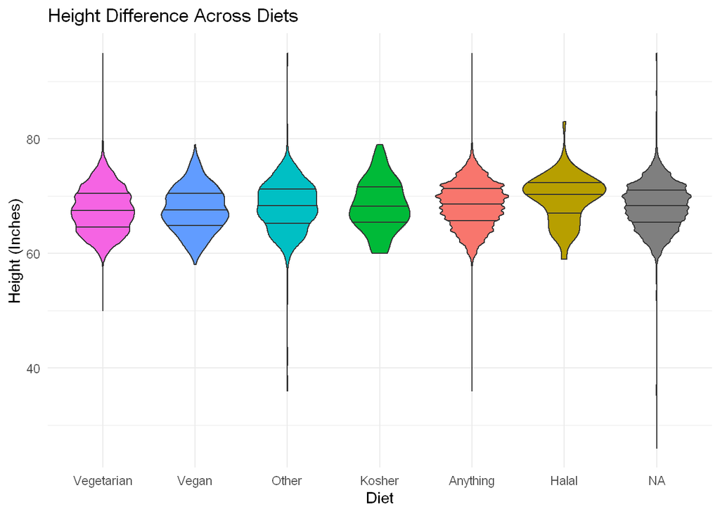

```r
okc %>%
  filter(height > 25) %>%
  mutate(diet = str_remove(diet,"strictly"),
         diet = str_remove(diet,"mostly"),
         diet = str_remove(diet, " "),
         diet = str_to_title(diet),
  )%>%
    ggplot(aes(x=reorder(diet,height),y=height,fill=diet))+
    geom_violin(  draw_quantiles = c(.25,.5,.75),show.legend = FALSE)+
    theme_minimal()+
   labs(title="Height Difference Across Diets",x="Diet",y="Height (Inches)")
```

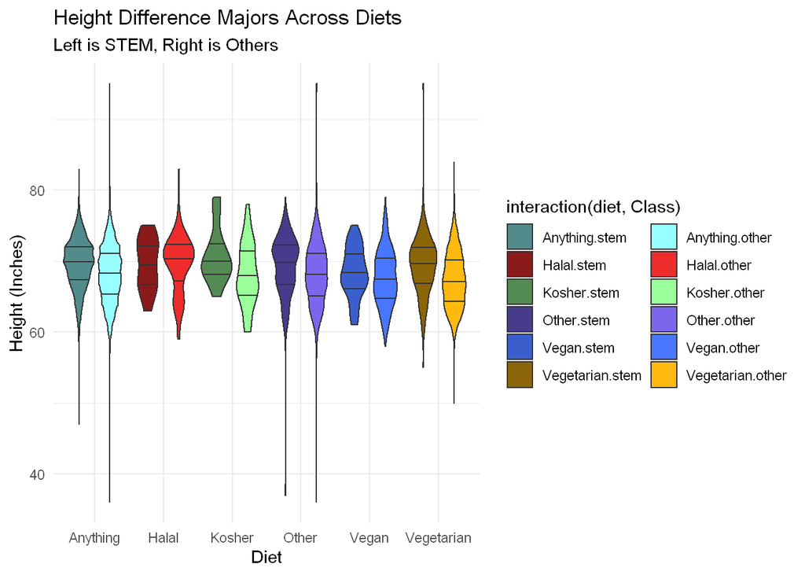

```r
okc %>%
  na.omit() %>%
  filter(height > 25) %>%
  mutate(diet = str_remove(diet,"strictly"),
         diet = str_remove(diet,"mostly"),
         diet = str_remove(diet, " "),
         diet = str_to_title(diet),
  )%>%
    ggplot(aes(x=diet,y=height,fill=interaction(diet,Class) )   ) + #Use fill=interaction(Class,diet) for better colouring - doesn't work here due to NAs
    geom_violin(  draw_quantiles = c(.25,.5,.75))+
    theme_minimal()+
   labs(title="Height Difference Majors Across Diets",subtitle ="Left is STEM, Right is Others" ,x="Diet",y="Height (Inches)")+
   scale_fill_manual(values=c("darkslategray4","firebrick4","palegreen4","slateblue4","royalblue3","darkgoldenrod4",
              "darkslategray1","firebrick2","palegreen1","slateblue2","royalblue1","darkgoldenrod1"))+
  theme(legend.position = "right")+
  guides(fill=guide_legend(ncol=2))
```

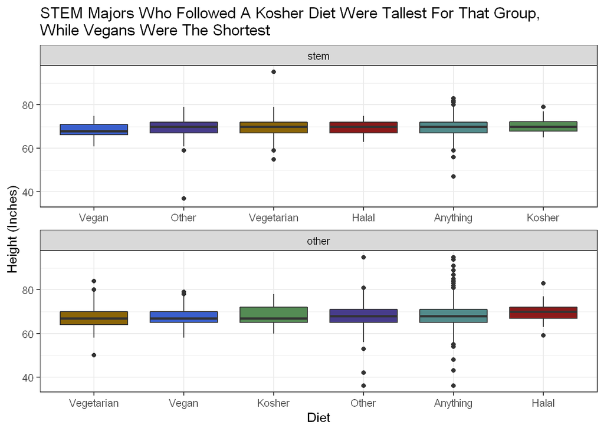

```r
okc %>%
  na.omit() %>%
  filter(height > 25) %>%
  mutate(diet = str_remove(diet,"strictly"),
         diet = str_remove(diet,"mostly"),
         diet = str_remove(diet, " "),
         diet = str_to_title(diet),
  )%>%
    ggplot(aes(x= tidytext::reorder_within(diet,height,Class)
               ,y=height,fill=diet)) + #Use fill=interaction(Class,diet) for better colouring - doesn't work here due to NAs
    #geom_violin(  draw_quantiles = c(.25,.5,.75))+
  geom_boxplot()+
  facet_wrap(.~Class,nrow=2,scales = "free_x")+
    theme_bw()+
   labs(title="STEM Majors Who Followed A Kosher Diet Were Tallest For That Group,\nWhile Vegans Were The Shortest",x="Diet",y="Height (Inches)")+
   scale_fill_manual(values=c("darkslategray4","firebrick4","palegreen4","slateblue4","royalblue3","darkgoldenrod4"))+
  theme(legend.position = "none")+
  tidytext::scale_x_reordered()
```

Seeing which combination of diet and class has the tallest individuals on average.

```r
okc %>%
  #na.omit() %>%
  filter(height > 25) %>%
  mutate(diet = str_remove(diet,"strictly"),
         diet = str_remove(diet,"mostly"),
         diet = str_remove(diet, " "),
         diet = str_to_title(diet),
  ) %>%
  group_by(Class,diet)%>%
  summarise(avg_height = mean(height),.groups="keep") %>%
  mutate( avg_height = avg_height/0.39370) %>%
  arrange(-avg_height) %>%
  ungroup() %>%
  pivot_wider(names_from = Class,values_from=avg_height)%>%
  mutate( avg = (stem+other)/2 )%>%
  arrange(-avg)
```

| diet | stem | other | avg |
| --- | --- | --- | --- |
| Halal | 176.8234 | 176.7685 | 176.7960 |
| Kosher | 179.7054 | 172.9669 | 176.3362 |
| Anything | 176.8687 | 173.3305 | 175.0996 |
| NA | 176.5763 | 172.7735 | 174.6749 |
| Other | 175.9794 | 173.1469 | 174.5632 |
| Vegetarian | 176.0799 | 170.9882 | 173.5341 |
| Vegan | 173.6186 | 171.7596 | 172.6891 |

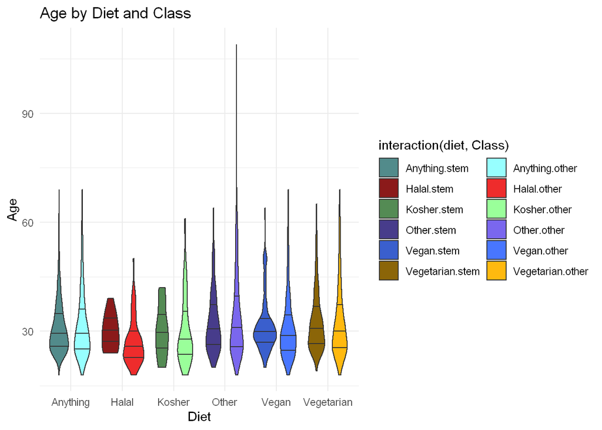

```r
okc %>%
  na.omit() %>%
  filter(height > 25) %>%
  mutate(diet = str_remove(diet,"strictly"),
         diet = str_remove(diet,"mostly"),
         diet = str_remove(diet, " "),
         diet = str_to_title(diet),
  )%>%
    ggplot(aes(x=diet,y=age,fill=interaction(diet,Class) )   ) + #Use fill=interaction(Class,diet) for better colouring - doesn't work here due to NAs
    geom_violin(  draw_quantiles = c(.25,.5,.75))+
    theme_minimal()+
   labs(title="Age by Diet and Class",x="Diet",y="Age")+
   scale_fill_manual(values=c("darkslategray4","firebrick4","palegreen4","slateblue4","royalblue3","darkgoldenrod4",
              "darkslategray1","firebrick2","palegreen1","slateblue2","royalblue1","darkgoldenrod1"))+
  theme(legend.position = "right")+
  guides(fill=guide_legend(ncol=2))
```

Is there a difference between major in different locations?

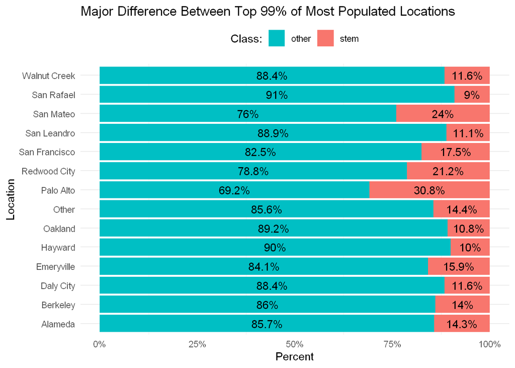

```r
okc %>%
  #filter( !is.na(diet)) %>%
  mutate(location = fct_lump_prop(location,prop=0.01),
         location =  str_to_title(location)
  ) %>%
  group_by(location,Class)%>%
  count(location)%>%
  ungroup(Class)%>%
  mutate(prop=n/sum(n)) %>%
  ungroup() %>%
  ggplot(aes(x= location,y=prop,fill=Class))+
  geom_col(position = position_stack() )+
  geom_text(aes(label=  paste0(  round(prop*100,1),"%" ) ), position = position_stack(vjust = 0.5)  )+
  scale_y_continuous(labels = scales::percent_format())+
  labs(title="Major Difference Between Top 99% of Most Populated Locations",x="Location",y="Percent",fill="Class:")+
  theme_minimal()+
  theme(legend.position = "top",
        panel.grid.major.x = element_blank() )+
  coord_flip()+
  guides(fill = guide_legend(reverse=TRUE))
```

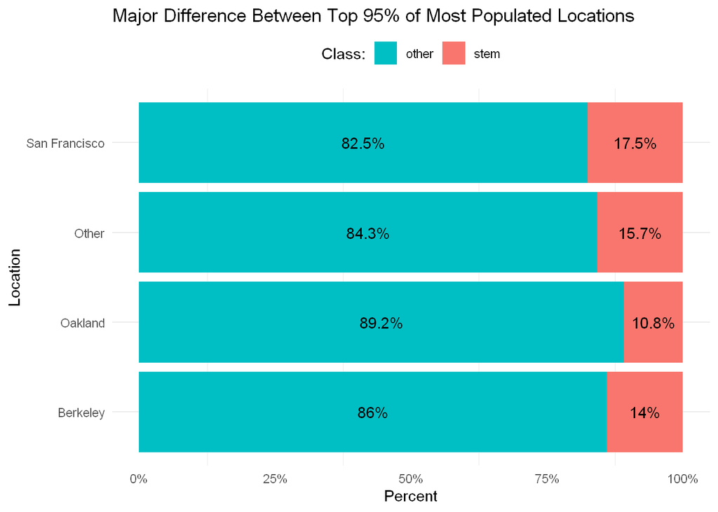

```r
okc %>%
  #filter( !is.na(diet)) %>%
  mutate(location = fct_lump_prop(location,prop=0.05),
         location =  str_to_title(location)
  ) %>%
  group_by(location,Class)%>%
  count(location)%>%
  ungroup(Class)%>%
  mutate(prop=n/sum(n)) %>%
  ungroup() %>%
  ggplot(aes(x= location,y=prop,fill=Class))+
  geom_col(position = position_stack() )+
  geom_text(aes(label=  paste0(  round(prop*100,1),"%" ) ), position = position_stack(vjust = 0.5)  )+
  scale_y_continuous(labels = scales::percent_format())+
  labs(title="Major Difference Between Top 95% of Most Populated Locations",x="Location",y="Percent",fill="Class:")+
  theme_minimal()+
  theme(legend.position = "top",
        panel.grid.major.x = element_blank() )+
  coord_flip()+
  guides(fill = guide_legend(reverse=TRUE))
```

# 2 Tidy Models

## 2.1 Creating Model Data

Armed with the information gathered from the EDA process, we can create a cleaned dataset to model on.

```r
okc_clean = okc %>%
  filter( height>25) %>%
  mutate(diet = str_remove(diet,"strictly"),
         diet = str_remove(diet,"mostly"),
         diet = str_remove(diet, " "),
         diet = str_to_title(diet),
         diet = factor(diet),
         location = fct_lump_prop(location,prop=0.05), #Lump people who appear less than 5% as Other
         location =  str_to_title(location),
         location = factor(location))%>%
  select(-date)
```

```r
skim(okc_clean)
```

Data summary

| Name | okc_clean |
| --- | --- |
| Number of rows | 59847 |
| Number of columns | 5 |
| _______________________ |  |
| Column type frequency: |  |
| factor | 3 |
| numeric | 2 |
| ________________________ |  |
| Group variables | None |

**Variable type: factor**

| skim_variable | n_missing | complete_rate | ordered | n_unique | top_counts |
| --- | --- | --- | --- | --- | --- |
| diet | 24355 | 0.59 | FALSE | 6 | Any: 27841, Veg: 4976, Oth: 1785, Veg: 698 |
| location | 0 | 1.00 | FALSE | 4 | San: 31061, Oth: 17364, Oak: 7213, Ber: 4209 |
| Class | 0 | 1.00 | FALSE | 2 | oth: 50310, ste: 9537 |

**Variable type: numeric**

| skim_variable | n_missing | complete_rate | mean | sd | p0 | p25 | p50 | p75 | p100 | hist |
| --- | --- | --- | --- | --- | --- | --- | --- | --- | --- | --- |
| age | 0 | 1 | 32.34 | 9.46 | 18 | 26 | 30 | 37 | 110 | ▇▂▁▁▁ |
| height | 0 | 1 | 68.30 | 3.94 | 26 | 66 | 68 | 71 | 95 | ▁▁▆▇▁ |

```r
set.seed(8888)

okc_split = initial_split(okc_clean,strata = Class)

okc_train = training(okc_split)
okc_test = testing(okc_split)
```

## 2.2 Create A Recipie

```r
okc_rec = recipe(Class~.,data=okc_train) %>%
  themis::step_downsample(Class) %>%
  step_unknown(diet) %>%
  step_dummy(all_nominal(),-all_outcomes()) %>%
  step_zv(all_predictors())
tree_rec = recipe(Class~.,data=okc_train) %>%
  step_unknown(diet)
```

## 2.3 Set Model Spec

```r
lgst_mod = logistic_reg() %>%
  set_engine("glm")

tree_mod = decision_tree(cost_complexity = tune(),
                          min_n = tune(),
                          tree_depth = tune()) %>%
  set_engine("rpart")%>%
  set_mode("classification")
```

## 2.4 Creating Worflow

```r
lgst_wf = workflow() %>%
    add_model(lgst_mod) %>%
    add_recipe(okc_rec)

tree_wf = workflow() %>%
  add_model(tree_mod)%>%
  add_recipe(tree_rec)
```

### 2.4.1 Finding the Hyperparameters For Tree Model

```r
#doParallel::registerDoParallel()

start = Sys.time()

set.seed(8888)
tree_res = tree_wf %>%
  tune_grid(    resamples = vfold_cv(okc_train,strata = Class),
                grid =  grid_max_entropy(cost_complexity(), min_n(),tree_depth(),size=20 ),
                control = control_grid(save_pred = TRUE))

#doParallel:::stopImplicitCluster()

end = Sys.time()

paste("Time Taken:",end-start)
```

```
## [1] "Time Taken: 1.93076254924138"
```

```r
tree_res %>%
  collect_metrics()
```

| cost_complexity | tree_depth | min_n | .metric | .estimator | mean | n | std_err | .config |
| --- | --- | --- | --- | --- | --- | --- | --- | --- |
| 0.0002728 | 8 | 17 | accuracy | binary | 0.8406407 | 10 | 0.0000232 | Model01 |
| 0.0002728 | 8 | 17 | roc_auc | binary | 0.5000000 | 10 | 0.0000000 | Model01 |
| 0.0000001 | 1 | 24 | accuracy | binary | 0.8406407 | 10 | 0.0000232 | Model02 |
| 0.0000001 | 1 | 24 | roc_auc | binary | 0.5000000 | 10 | 0.0000000 | Model02 |
| 0.0000042 | 6 | 3 | accuracy | binary | 0.8405962 | 10 | 0.0000492 | Model03 |
| 0.0000042 | 6 | 3 | roc_auc | binary | 0.6079312 | 10 | 0.0033329 | Model03 |
| 0.0787769 | 12 | 20 | accuracy | binary | 0.8406407 | 10 | 0.0000232 | Model04 |
| 0.0787769 | 12 | 20 | roc_auc | binary | 0.5000000 | 10 | 0.0000000 | Model04 |
| 0.0000000 | 2 | 39 | accuracy | binary | 0.8406407 | 10 | 0.0000232 | Model05 |
| 0.0000000 | 2 | 39 | roc_auc | binary | 0.5000000 | 10 | 0.0000000 | Model05 |
| 0.0425398 | 3 | 20 | accuracy | binary | 0.8406407 | 10 | 0.0000232 | Model06 |
| 0.0425398 | 3 | 20 | roc_auc | binary | 0.5000000 | 10 | 0.0000000 | Model06 |
| 0.0000000 | 13 | 2 | accuracy | binary | 0.8339795 | 10 | 0.0005051 | Model07 |
| 0.0000000 | 13 | 2 | roc_auc | binary | 0.6326370 | 10 | 0.0028302 | Model07 |
| 0.0000028 | 11 | 4 | accuracy | binary | 0.8379674 | 10 | 0.0001622 | Model08 |
| 0.0000028 | 11 | 4 | roc_auc | binary | 0.6370359 | 10 | 0.0037158 | Model08 |
| 0.0001168 | 13 | 39 | accuracy | binary | 0.8406407 | 10 | 0.0000232 | Model09 |
| 0.0001168 | 13 | 39 | roc_auc | binary | 0.5000000 | 10 | 0.0000000 | Model09 |
| 0.0000150 | 8 | 34 | accuracy | binary | 0.8406407 | 10 | 0.0000232 | Model10 |
| 0.0000150 | 8 | 34 | roc_auc | binary | 0.5000000 | 10 | 0.0000000 | Model10 |
| 0.0000000 | 14 | 33 | accuracy | binary | 0.8397497 | 10 | 0.0002963 | Model11 |
| 0.0000000 | 14 | 33 | roc_auc | binary | 0.6263418 | 10 | 0.0040858 | Model11 |
| 0.0000000 | 13 | 16 | accuracy | binary | 0.8381233 | 10 | 0.0001983 | Model12 |
| 0.0000000 | 13 | 16 | roc_auc | binary | 0.6349699 | 10 | 0.0032979 | Model12 |
| 0.0344537 | 7 | 31 | accuracy | binary | 0.8406407 | 10 | 0.0000232 | Model13 |
| 0.0344537 | 7 | 31 | roc_auc | binary | 0.5000000 | 10 | 0.0000000 | Model13 |
| 0.0356874 | 11 | 37 | accuracy | binary | 0.8406407 | 10 | 0.0000232 | Model14 |
| 0.0356874 | 11 | 37 | roc_auc | binary | 0.5000000 | 10 | 0.0000000 | Model14 |
| 0.0000000 | 8 | 35 | accuracy | binary | 0.8406407 | 10 | 0.0000232 | Model15 |
| 0.0000000 | 8 | 35 | roc_auc | binary | 0.5000000 | 10 | 0.0000000 | Model15 |
| 0.0000001 | 8 | 16 | accuracy | binary | 0.8404848 | 10 | 0.0000888 | Model16 |
| 0.0000001 | 8 | 16 | roc_auc | binary | 0.6133944 | 10 | 0.0067255 | Model16 |
| 0.0185553 | 5 | 2 | accuracy | binary | 0.8406407 | 10 | 0.0000232 | Model17 |
| 0.0185553 | 5 | 2 | roc_auc | binary | 0.5000000 | 10 | 0.0000000 | Model17 |
| 0.0000337 | 15 | 15 | accuracy | binary | 0.8380788 | 10 | 0.0002459 | Model18 |
| 0.0000337 | 15 | 15 | roc_auc | binary | 0.6258610 | 10 | 0.0048791 | Model18 |
| 0.0000000 | 1 | 4 | accuracy | binary | 0.8406407 | 10 | 0.0000232 | Model19 |
| 0.0000000 | 1 | 4 | roc_auc | binary | 0.5000000 | 10 | 0.0000000 | Model19 |
| 0.0000019 | 12 | 26 | accuracy | binary | 0.8397496 | 10 | 0.0001654 | Model20 |
| 0.0000019 | 12 | 26 | roc_auc | binary | 0.6187251 | 10 | 0.0138764 | Model20 |

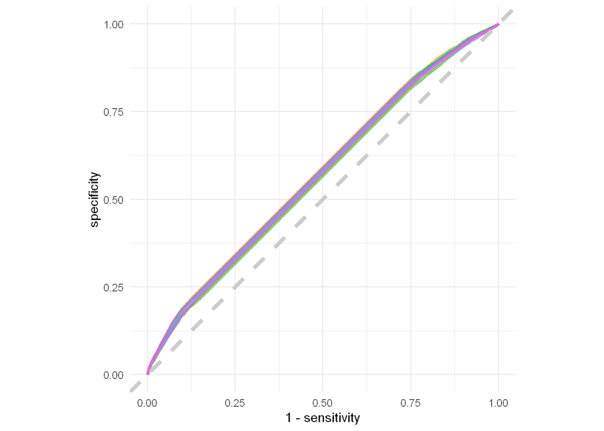

```r
tree_res %>%
  collect_predictions() %>%
  group_by(id) %>%
  roc_curve(truth=Class,.pred_stem) %>%
  ggplot(aes(x=1-sensitivity,y=specificity,col=id))+
  geom_path(show.legend = FALSE, alpha = 0.6, size = 1.2) +
  geom_abline(lty = 2, color = "gray80", size = 1.5) +
  theme_minimal()+
  coord_equal()
```

We do not see great results.

```r
tree_res %>%
  select_best(metric="roc_auc")
```

| cost_complexity | tree_depth | min_n | .config |
| --- | --- | --- | --- |
| 2.8e-06 | 11 | 4 | Model08 |

### 2.4.2 Estimate Logistic Regression

```r
lgst_fit = fit(lgst_wf,data=okc_train)
```

```r
coefs = lgst_fit %>%
  pull_workflow_fit() %>%
  tidy()

coefs
```

| term | estimate | std.error | statistic | p.value |
| --- | --- | --- | --- | --- |
| (Intercept) | 7.1115601 | 0.3380275 | 21.0384057 | 0.0000000 |
| age | -0.0002797 | 0.0019638 | -0.1424038 | 0.8867610 |
| height | -0.1024688 | 0.0046800 | -21.8949886 | 0.0000000 |
| diet_Halal | 0.0515111 | 0.4466523 | 0.1153270 | 0.9081859 |
| diet_Kosher | 0.8325171 | 0.4272224 | 1.9486740 | 0.0513344 |
| diet_Other | 0.2191746 | 0.1094641 | 2.0022506 | 0.0452578 |
| diet_Vegan | 0.3649844 | 0.1702970 | 2.1432231 | 0.0320952 |
| diet_Vegetarian | 0.1336157 | 0.0652959 | 2.0463123 | 0.0407257 |
| diet_unknown | 0.1185543 | 0.0368114 | 3.2205865 | 0.0012793 |
| location_Oakland | 0.2397544 | 0.0868536 | 2.7604429 | 0.0057723 |
| location_Other | -0.0805340 | 0.0742326 | -1.0848876 | 0.2779714 |
| location_San.Francisco | -0.2217720 | 0.0710128 | -3.1229854 | 0.0017903 |

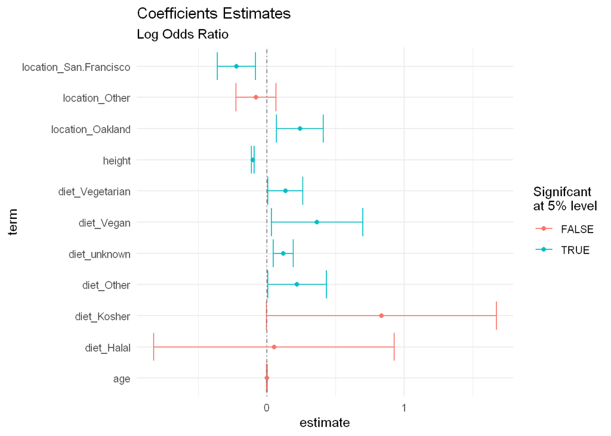

```r
coefs %>%
  filter(term!="(Intercept)")%>%
  mutate(Significant = if_else(p.value < 0.05,"TRUE","FALSE")  ) %>%
ggplot(aes(y=term,x=estimate,col=Significant))+
  geom_point()+
  geom_errorbar(aes(xmax=estimate+1.96*std.error,
                xmin=estimate-1.96*std.error
  ))+
  geom_vline(xintercept=0,lty=4,col="grey50")+
  theme_minimal()+
  labs(title="Coefficients Estimates",subtitle="Log Odds Ratio",col="Signifcant\nat 5% level")
```

We see that Age is not a significant variable in determining the major of a person.

The baseline of the model is someone from Berkeley and has a diet of Anything. From a diet perspective, we see that someone being: Vegetarian, Vegan Unknown or Other, increases the odds of someone having a STEM Major. We do not see evidence that Kosher or Halal are different to Anything.

```r
coefs %>%
  filter(term !="(Intercept)")%>%
  mutate(Odds_Ratio = exp(estimate)) %>%
  select(term,Odds_Ratio)
```

| term | Odds_Ratio |
| --- | --- |
| age | 0.9997204 |
| height | 0.9026063 |
| diet_Halal | 1.0528608 |
| diet_Kosher | 2.2990986 |
| diet_Other | 1.2450486 |
| diet_Vegan | 1.4404915 |
| diet_Vegetarian | 1.1429536 |
| diet_unknown | 1.1258680 |
| location_Oakland | 1.2709370 |
| location_Other | 0.9226235 |
| location_San.Francisco | 0.8010980 |

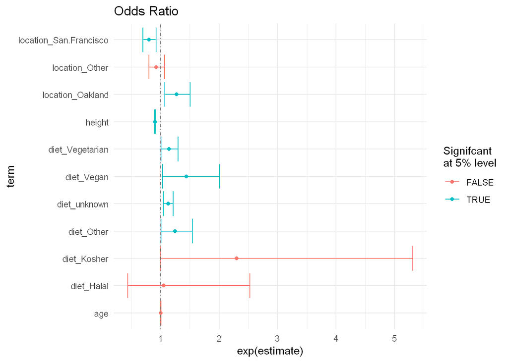

```r
coefs %>%
  filter(term != "(Intercept)") %>%
  mutate(Significant = if_else(p.value < 0.05, "TRUE", "FALSE")) %>%
  ggplot(aes(
    y = term,
    x = exp(estimate),
    col = Significant
  )) +
  geom_point() +
  geom_errorbar(aes(xmax = exp(estimate + 1.96 * std.error),
                xmin = exp(estimate - 1.96 * std.error))
                )+
  geom_vline(xintercept = 1,
             lty = 4,
             col = "grey50") +
  theme_minimal() +
  labs(title = "Odds Ratio",col="Signifcant\nat 5% level")
```

### 2.4.3 Evaluating Logistic Regression Performance

We will use resampling to get an estimate on how the model performed on the training set.

```r
set.seed(8888)
lgst_train_rs = lgst_wf %>%
  fit_resamples(
   resamples = vfold_cv(okc_train,strata = Class),
   metrics = metric_set(accuracy,roc_auc, sens, spec),
    control = control_resamples(save_pred = TRUE)
 )
```

```r
lgst_train_rs %>%
  collect_metrics()
```

| .metric | .estimator | mean | n | std_err |
| --- | --- | --- | --- | --- |
| accuracy | binary | 0.5713578 | 10 | 0.0031953 |
| roc_auc | binary | 0.6221339 | 10 | 0.0021738 |
| sens | binary | 0.6260325 | 10 | 0.0048708 |
| spec | binary | 0.5609937 | 10 | 0.0035646 |

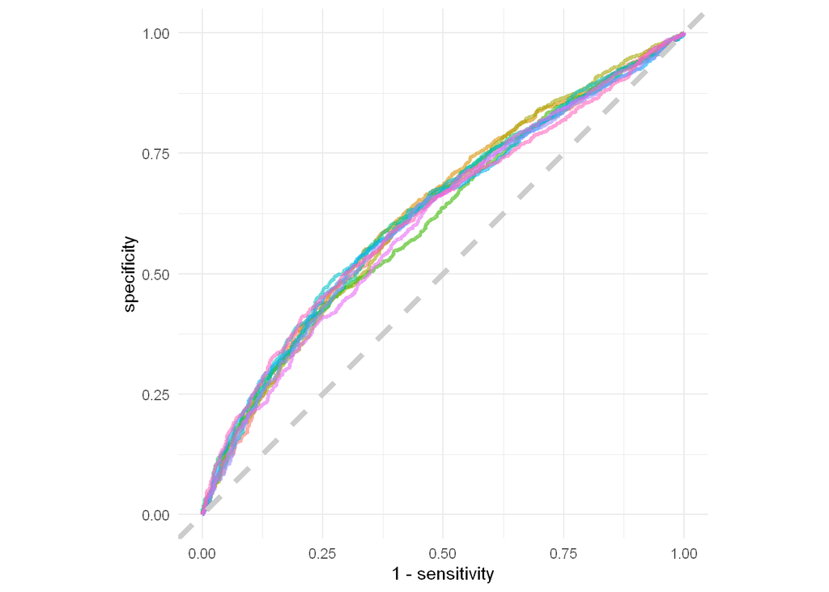

```r
lgst_train_rs %>%
  collect_predictions()%>%
  group_by(id)  %>%
  roc_curve(truth=Class,.pred_stem) %>%
  ggplot(aes(x=1-sensitivity,y=specificity,col=id))+
  geom_path(show.legend = FALSE, alpha = 0.6, size = 1.2) +
  geom_abline(lty = 2, color = "gray80", size = 1.5) +
  theme_minimal()+
  coord_equal()
```

Below we can see the ROC Curve, we don’t get good results on the tree model

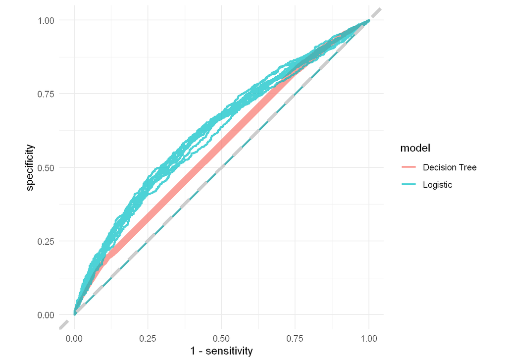

```r
lgst_train_rs %>%
  collect_predictions()%>%
  group_by(id)%>%
  roc_curve(truth=Class,.pred_stem) %>%
    mutate(model="Logistic") %>%

  bind_rows(
    tree_res %>%
  collect_predictions()%>%
  group_by(id)%>%
  roc_curve(truth=Class,.pred_stem) %>%
    mutate(model="Decision Tree")
) %>%
  ggplot(aes(x=1-sensitivity,y=specificity,col=model))+
  geom_path(alpha = 0.7, size = 1) +
  geom_abline(lty = 2, color = "gray80", size = 1.5) +
  theme_minimal()+
  coord_equal()
```

### 2.4.4 Using Best Tree

```r
best_tree = tree_res %>% select_best("roc_auc")

final_tree_wf =
  tree_wf %>%
  finalize_workflow(best_tree)

final_tree_wf
```

```
## == Workflow ================================================================================================================================================================
## Preprocessor: Recipe
## Model: decision_tree()
##
## -- Preprocessor ------------------------------------------------------------------------------------------------------------------------------------------------------------
## 1 Recipe Step
##
## * step_unknown()
##
## -- Model -------------------------------------------------------------------------------------------------------------------------------------------------------------------
## Decision Tree Model Specification (classification)
##
## Main Arguments:
##   cost_complexity = 2.81310986908408e-06
##   tree_depth = 11
##   min_n = 4
##
## Computational engine: rpart
```

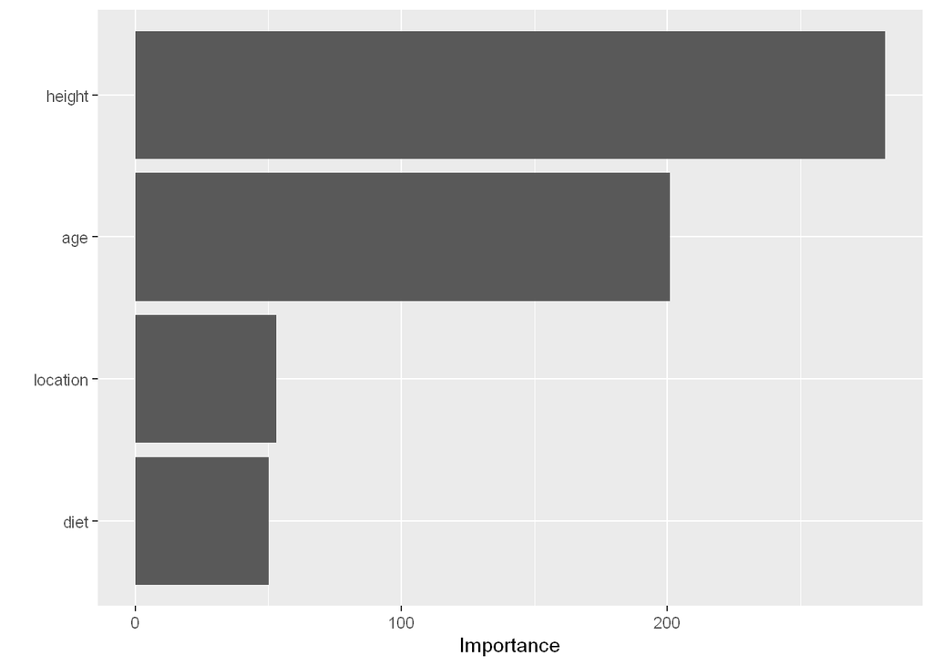

```r
library(vip)

final_tree = final_tree_wf %>% fit(data=okc_train)

pull_final_tree= final_tree %>%
  pull_workflow_fit()

pull_final_tree %>%
  vip()
```

# 3 Performance on Test Set

We can see the roc_auc and accuracy.

```r
predict(lgst_fit,new_data = okc_test,type="prob") %>%
   bind_cols(  okc_test %>% select(Class)  ) %>%
   roc_auc(truth=Class, .pred_stem) %>%
  mutate(model="Logistic") %>%
  bind_rows(

predict(final_tree,new_data = okc_test,type="prob") %>%
   bind_cols(  okc_test %>% select(Class)  ) %>%
   roc_auc(truth=Class, .pred_stem)%>%
  mutate(model="Decision Tree")
) %>%
  select(model,.estimate,.metric) %>%

  bind_rows(


predict(lgst_fit,new_data = okc_test)   %>%
   bind_cols(  okc_test %>% select(Class)  ) %>%
   accuracy(truth=Class, .pred_class) %>%
  mutate(model="Logistic") %>%
  bind_rows(

predict(final_tree,new_data = okc_test)   %>%
   bind_cols(  okc_test %>% select(Class)  ) %>%
   accuracy(truth=Class, .pred_class) %>%
  mutate(model="Decision Tree")
) %>%
  select(model,.estimate,.metric)

) %>%
  pivot_wider(names_from = .metric,values_from=.estimate)
```

| model | roc_auc | accuracy |
| --- | --- | --- |
| Logistic | 0.6343331 | 0.5860571 |
| Decision Tree | 0.6589016 | 0.8389145 |

In terms of roc_auc and accuracy, the decision tree is superior over the logistic model.

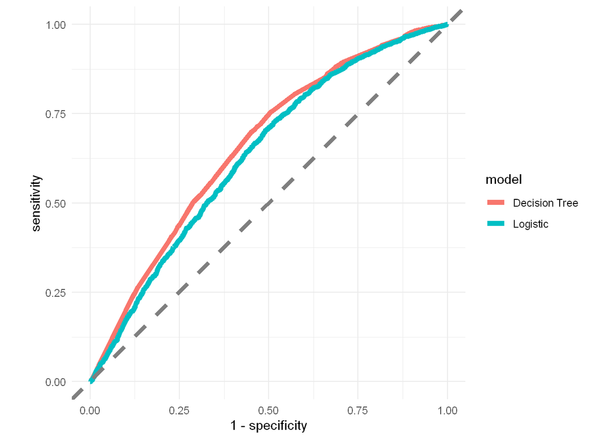

```r
predict(lgst_fit,new_data = okc_test,type="prob") %>%
   bind_cols(  okc_test %>% select(Class)  ) %>%
   roc_curve(truth=Class, .pred_stem)%>%
  mutate(model="Logistic") %>%
  bind_rows(

predict(final_tree,new_data = okc_test,type="prob") %>%
   bind_cols(  okc_test %>% select(Class)  ) %>%
   roc_curve(truth=Class, .pred_stem)%>%
  mutate(model="Decision Tree")
) %>%
  ggplot(aes(x=1-specificity,y=sensitivity,col=model))+
  geom_path(size=2)+
  geom_abline(slope=1,col="grey50",size=1.5,lty=8)+
  theme_minimal()+
  coord_equal()
```

### 3.0.1 Confusion Matrices

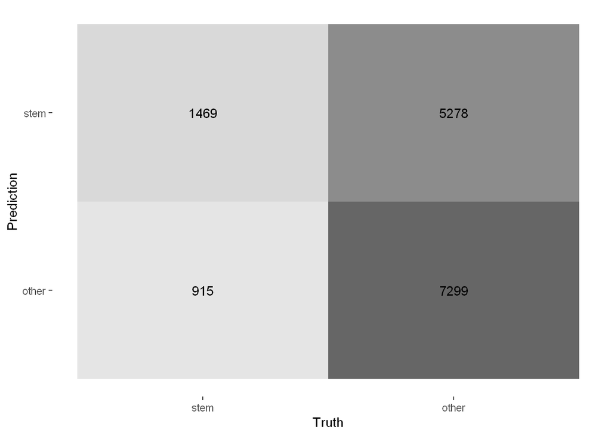

```r
predict(lgst_fit,new_data = okc_test)   %>%
   bind_cols(  okc_test %>% select(Class)  ) %>%
  conf_mat(truth=Class,.pred_class) %>%
    autoplot(type="heatmap")
```

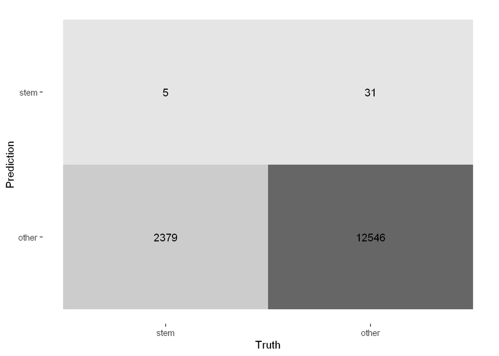

```r
predict(final_tree,new_data = okc_test)   %>%
   bind_cols(  okc_test %>% select(Class)  ) %>%
  conf_mat(truth=Class,.pred_class) %>%
  autoplot(type="heatmap")
```

However, upon further inspection, we see that the tree is just predicting `other` many times. The base line is

```r
paste0("Base Accuracy: ",round((12546+31)/nrow(okc_test) *100,1),"%")
```

```
## [1] "Base Accuracy: 84.1%"
```

So in-fact, we did worse than always predicting the most common occurrence in our training set, which was to predict that someone was not a STEM major.

# 4 Post-Hoc Analysis

```r
summary(okc_train)
```

```
##       age                 diet           height              location
##  Min.   : 18.00   Anything  :20839   Min.   :26.0   Berkeley     : 3156
##  1st Qu.: 26.00   Halal     :   58   1st Qu.:66.0   Oakland      : 5391
##  Median : 30.00   Kosher    :   90   Median :68.0   Other        :13040
##  Mean   : 32.36   Other     : 1319   Mean   :68.3   San Francisco:23299
##  3rd Qu.: 37.00   Vegan     :  532   3rd Qu.:71.0
##  Max.   :110.00   Vegetarian: 3745   Max.   :95.0
##                   NA's      :18303
##    Class
##  stem : 7153
##  other:37733
##
##
##
##
##
```

We create a fake dataset to see what the models are predicting.

```r
fake_data_2 = expand_grid(
  age = (18:70),
  height = (60:80),
  location = c("San Francisco", "Oakland", "Other", "Berkeley"),
  diet = c("Halal", "Kosher","Anything","Other",NA, "Vegan", "Vegetarian")
)
```

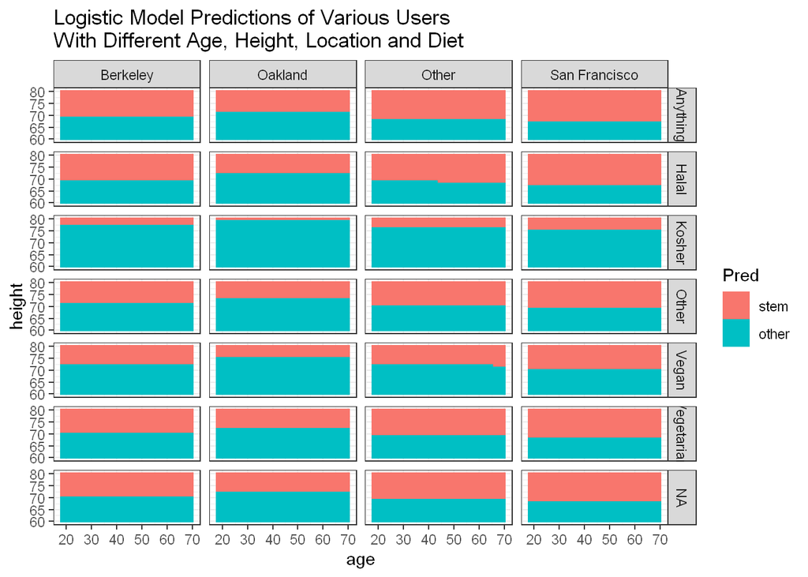

```r
predict(lgst_fit,new_data=fake_data_2) %>%
  rename(Pred =  .pred_class) %>%
  bind_cols(fake_data_2) %>%
  ggplot(aes(x=age,y=height,fill=Pred))+
  geom_tile()+
  theme_bw()+
  facet_grid(diet~location)+
  labs(title="Logistic Model Predictions of Various Users\nWith Different Age, Height, Location and Diet")
```

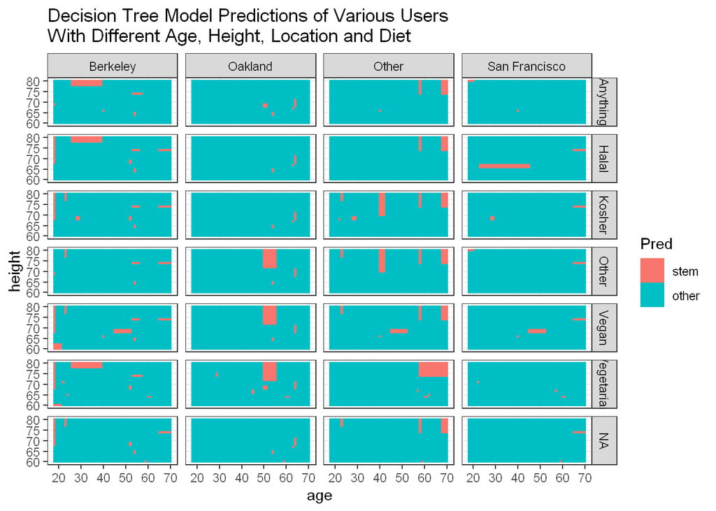

```r
predict(final_tree,new_data=fake_data_2) %>%
  rename(Pred =  .pred_class) %>%
  bind_cols(fake_data_2) %>%
  ggplot(aes(x=age,y=height,fill=Pred))+
  geom_tile()+
  theme_bw()+
  facet_grid(diet~location)+
  labs(title="Decision Tree Model Predictions of Various Users\nWith Different Age, Height, Location and Diet")
```

```r
lgst_cmb_preds= predict(lgst_fit,new_data = okc_test) %>%
  bind_cols(okc_test) %>%
  mutate( Result =   case_when( .pred_class == "stem"  & Class=="stem"  ~ "TP",
                                 .pred_class == "other"  & Class=="other"  ~ "TN",
                                 .pred_class == "stem"  & Class=="other"  ~ "FP",
                                  .pred_class == "other"  & Class=="stem"  ~ "FN"
                                )) %>%
  rename(Pred = .pred_class)
```

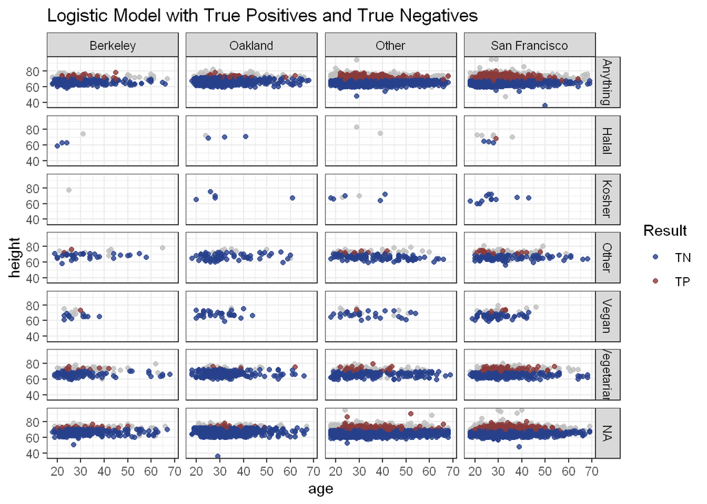

```r
  ggplot()+
  geom_point( data= lgst_cmb_preds%>%filter(Result %in% c("FN","FP")) ,mapping=aes(x=age,y=height),col="grey",alpha=0.8)+
  geom_point( data= lgst_cmb_preds%>%filter(!Result %in% c("FN","FP")) ,mapping=aes(x=age,y=height,col=Result),alpha=0.8)+
  theme_bw()+
  facet_grid(diet~location)+
  scale_color_manual(values = c("royalblue4","indianred4"))+
  labs(title="Logistic Model with True Positives and True Negatives")
```

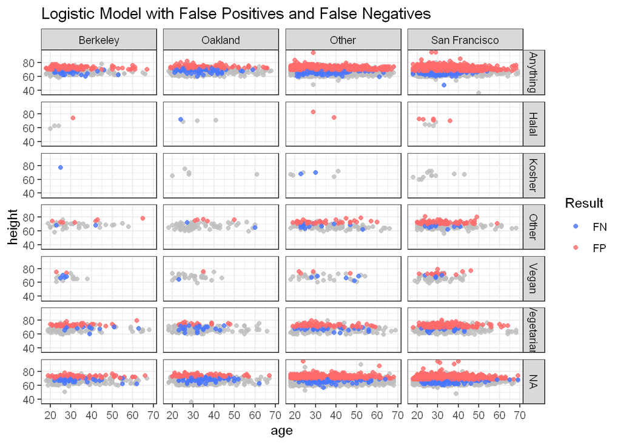

```r
  ggplot()+
  geom_point( data= lgst_cmb_preds%>%filter(!Result %in% c("FN","FP")) ,mapping=aes(x=age,y=height),col="grey",alpha=0.8)+
  geom_point( data= lgst_cmb_preds%>%filter(Result %in% c("FN","FP")) ,mapping=aes(x=age,y=height,col=Result),alpha=0.8)+
  theme_bw()+
  facet_grid(diet~location)+
  scale_color_manual(values = c("royalblue1","indianred1"))+
  labs(title="Logistic Model with False Positives and False Negatives")
```

We see that the Logistic Model harshly classifies based on height.

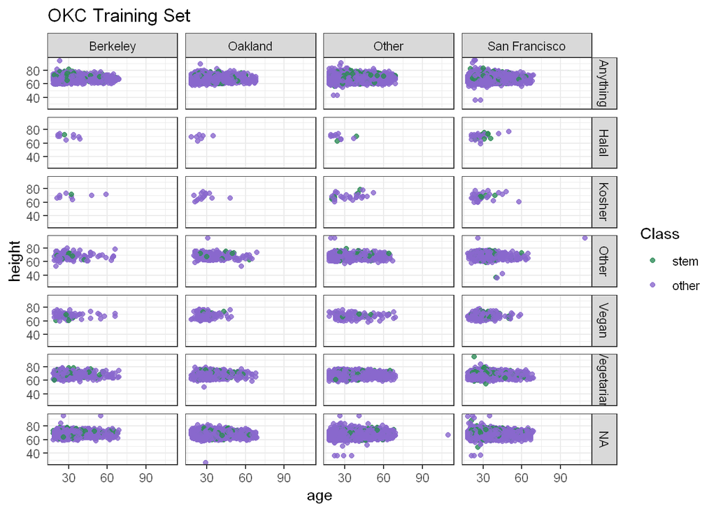

```r
ggplot(okc_train,aes(x=age,y=height,col=Class))+
  geom_point(alpha=0.8)+
  theme_bw()+
  facet_grid(diet~location)+
  scale_color_manual(values = c("seagreen","mediumpurple3"))+
  labs(title="OKC Training Set")
```